**Code Visibility and Accessibility**

The R code chunks in this project are hidden by default. The `Code` drop down at the beginning of the project allows for all chunks to be shown at once for better readability. Alternatively, individual code sections can be shown by clicking the `Code` button above each chunk. Clicking the button again will hide the code.

# Problem and Objective

Canada’s labour market is influenced by complex and dynamic economic forces, from industrial shifts to global recessions. Sudden changes in unemployment create financial and operational risks for businesses and complicate policy planning. Accurate forecasting of unemployment trends is critical for organisations to optimise workforce allocation, anticipate economic risks, and make informed decisions in uncertain environments.

The objective of this project is to apply statistical forecasting models to historical unemployment data and provide insights that enable data-driven decisions for business strategy and policy planning. By evaluating a range of statistical forecasting models, the project assesses how different methodologies perform when applied to realistic business scenarios.

# Data Analysis

## Exploratory analysis

The M3 competition dataset covers multiple business-relevant domains including finance, economics, and demographics. Each time series represents the historical behaviour of a key operational or market variable, such as sales volumes, asset prices, or production output, observed at regular intervals. These data structures closely mirror the types of information used by organisations for budgeting, demand planning, and performance monitoring.

The analysis focuses on series ID 1394 from the M3 forecasting competition, which tracks quarterly demographic data, specifically unemployment in Canada. This time series is valuable for analysts and researchers studying labour market trends in Canada and could aid in developing forecasting models to predict future unemployment based on historical patterns. We assume the data has been adjusted to represent per capita data. A summary of series 1394 is provided below.

```r
# Load the data
frequency <- 4
data <- M3[[1394]]
data <- subset(data, frequency == frequency)

# Assign the historical data to a variable for training the model
training_data <- data$x

# Assign the future data points for testing the model's predictions
test_data <- data$xx

{ cat("M3 competition series ID 1394\n"); print(data) }
```

```
M3 competition series ID 1394
$st
[1] "Q749"

$type
[1] "DEMOGRAPHIC"

$period
[1] "QUARTERLY"

$description
[1] "UNEMPLOYMENT- CANADA"

$sn
[1] "N1394"

$x
     Qtr1 Qtr2 Qtr3 Qtr4
1962 5610 3730 2820 3460
1963 5460 3720 2720 3050
1964 4630 3260 2430 2660
1965 3970 2980 2100 2140
1966 3520 2580 2260 2330
1967 3920 3200 2500 2990
1968 4780 3990 3170 3330
1969 4630 4000 3150 3500
1970 5180 5290 4550 4780
1971 6640 5840 4680 4930
1972 6450 5710 5020 5300
1973 6500 5220 4380 4700

$xx
     Qtr1 Qtr2 Qtr3 Qtr4
1974 6240 5200 4480 5070
1975 8320 7380 6210 6380

$h
[1] 8

$n
[1] 48
```

Within the context of the M3 competition data set, ‘x’ serves as the historical (a.k.a. training) time series data from 1962 to 1973, which is used to develop and calibrate forecasting models, while ‘xx’ acts as the future (a.k.a. test) data set from 1974 to 1975, which is used to evaluate the performance and accuracy of the models’ predictions.

Producing a time series plot of the historical data (Figure 1) and its summary will help gain insights into the data’s characteristics.

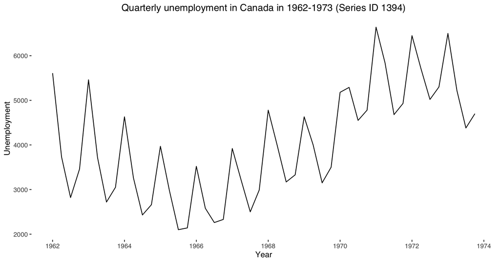

Figure 1: Quarterly unemployment in Canada in 1962-1973

```r
# Generate a time series plot of the training data
autoplot(training_data,
         type = "l",
         xlab = "Year",
         ylab = "Unemployment",
         main = "Quarterly unemployment in Canada in 1962-1973 (Series ID 1394)") +
    theme_tufte(base_family = "Helvetica") +
    theme(
      plot.title = element_text(hjust = 0.5),
      legend.position = "top"
    )
```

```r
kableExtra::kbl(glance(summary(training_data)), digits = 2, caption = "Summary of the quarterly unemployment in Canada in 1962-1973")|>
  kable_styling(
    position = "center",
    full_width = FALSE
  )
```

Table 1: Summary of the quarterly unemployment in Canada in 1962-1973

| minimum | q1 | median | mean | q3 | maximum |
| --- | --- | --- | --- | --- | --- |
| 2100 | 3035 | 3945 | 4036.67 | 4952.5 | 6640 |

The series exhibits a downward trend before 1966, followed by a clear upward trend starting in 1966, indicating an increase in the unemployed since then. A strong seasonal pattern is evident in Figure 2, with peaks and troughs corresponding to particular times of the year (Q1 and Q3, respectively) (Figure 3), suggesting likely annual seasonality influenced by various factors related to economic activity, societal habits, and institutional schedules.

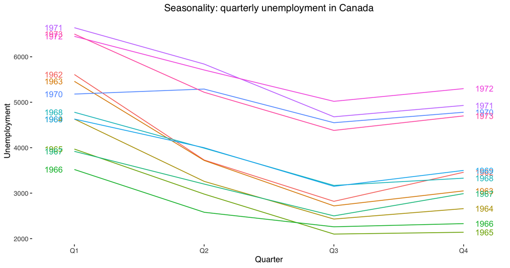

Figure 2: Seasonality plot of the quarterly unemployment in Canada in 1962-1973

```r
ggseasonplot(training_data, year.labels=TRUE, year.labels.left=TRUE) +
  ylab("Unemployment") +
  ggtitle("Seasonality: quarterly unemployment in Canada")+
    theme_tufte(base_family = "Helvetica") +
    theme(
      plot.title = element_text(hjust = 0.5),
      legend.position = "top"
    )
```

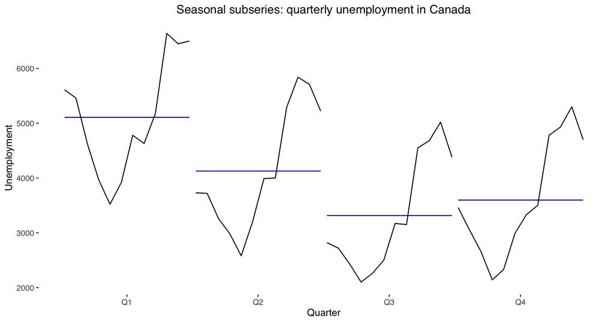

Figure 3: Seasonal subseries plot of the quarterly unemployment in Canada in 1962-1973

```r
ggsubseriesplot(training_data) +
  ylab("Unemployment") +
  ggtitle("Seasonal subseries: quarterly unemployment in Canada")+
    theme_tufte(base_family = "Helvetica") +
    theme(
      plot.title = element_text(hjust = 0.5),
      legend.position = "top"
    )
```

The lagged scatter plots of the quarterly Canadian unemployment (Figure 4) reveal a strongly positive relationship at lag 4, reflecting the strong seasonality in the data.

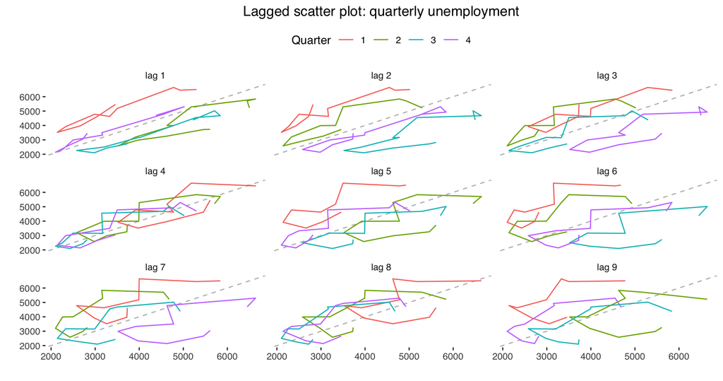

Figure 4: Lagged scatter plots of the quarterly unemployment in Canada in 1962-1973

```r
gglagplot(training_data) +
  ggtitle("Lagged scatter plot: quarterly unemployment") +
    theme(legend.position = "bottom",
          axis.text.x = element_text(angle = 45, hjust = 1)) +
    theme_tufte(base_family = "Helvetica") +
    theme(
      plot.title = element_text(hjust = 0.5),
      legend.position = "top"
    )
```

As the data are both trended and seasonal, we observe the slow decay in autocorrelation associated with the trend component alongside more significant spikes at lags matching the seasonal period in Figure 5.

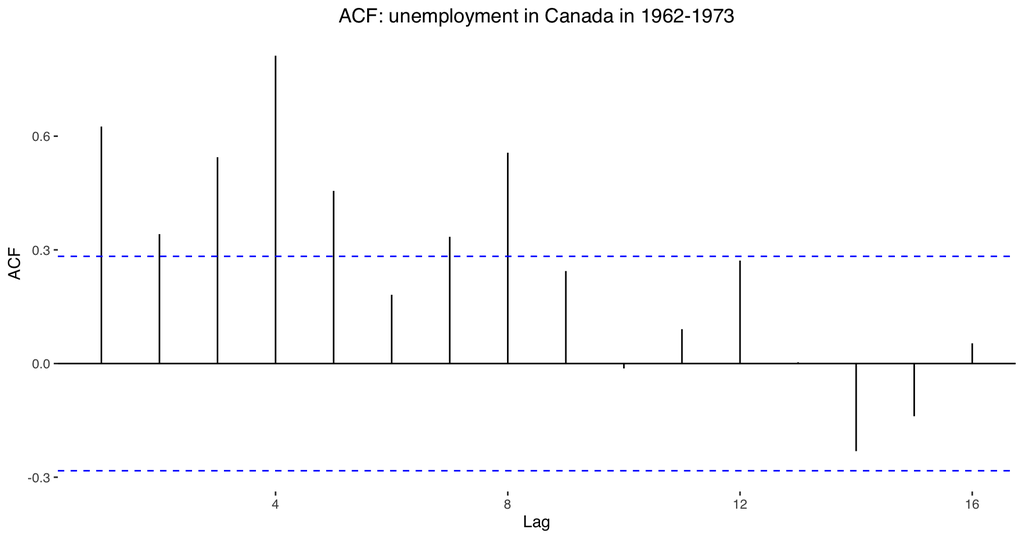

Figure 5: Autocorrelation Function (ACF) plot of the quarterly unemployment in Canada in 1962-1973

```r
ggAcf(training_data, main = "ACF: unemployment in Canada in 1962-1973")+
    theme_tufte(base_family = "Helvetica") +
    theme(
      plot.title = element_text(hjust = 0.5),
      legend.position = "top"
    )
```

As the data exhibits both trend and seasonality, decomposition can be a valuable insight by separating the time series into trend, seasonality, and residual components. Upon decomposing the time series, the multiplicative type of decomposition effectively subtracts the seasonal and trend-cycle components from the training data in Figure 6.

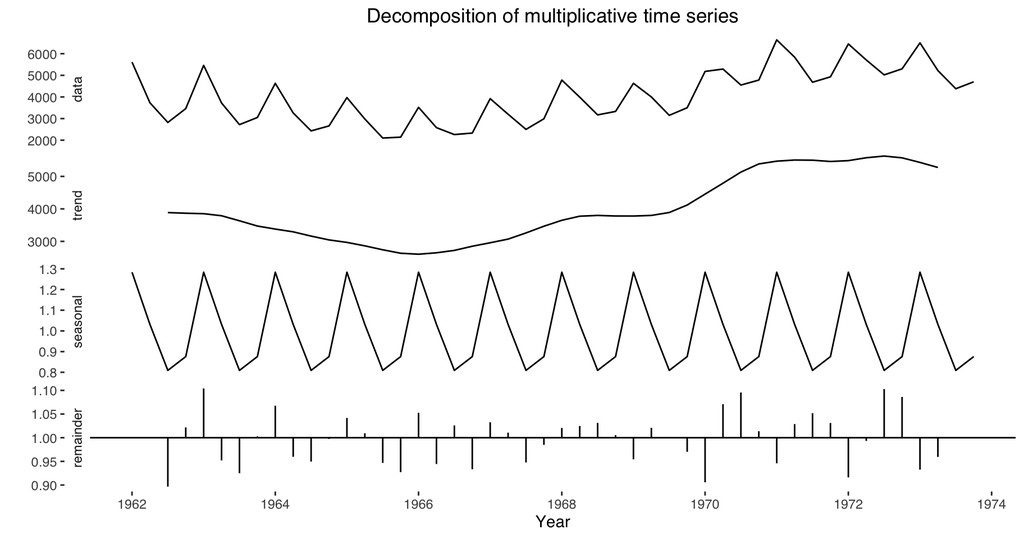

Figure 6: Decomposed quarterly unemployment in Canada in 1962-1973

```r
training_decomposed <- decompose(training_data, type = "multiplicative")
autoplot(training_decomposed)+xlab("Year")+
    theme_tufte(base_family = "Helvetica") +
    theme(
      plot.title = element_text(hjust = 0.5),
      legend.position = "top"
    )
```

However, discerning longer-term cyclical fluctuations in Canada’s unemployment due to broader economic conditions within the limited time frame of the plot (spanning from 1962 to 1973) may be challenging. Extended data covering a more prolonged period would be necessary to reliably identify and confirm these broader economic trends and their impact on unemployment.

Based on the above, any forecasts of this series would need to capture the trend and seasonal patterns.

Detecting outliers in time series data in Figure 7 is critical as they can significantly impact analysis and forecasts.

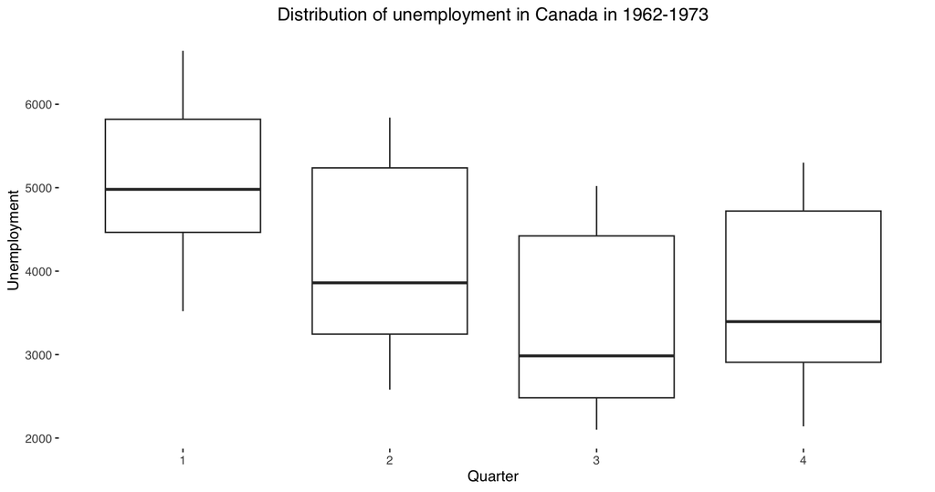

Figure 7: Distribution of unemployment in Canada in 1962-1973 per quarter

```r
# Ensure the time series has the correct frequency set
training_ts <- ts(training_data, frequency = 4)

# Convert the time series to a data frame for plotting
# Create a factor indicating the quarter
df <- data.frame(
  Value = as.numeric(training_ts),
  Quarter = factor(rep(1:4, length.out = length(training_ts)))
)

ggplot(df, aes(x = Quarter, y = Value)) +
  geom_boxplot() +
  labs(title = "Distribution of unemployment in Canada in 1962-1973", x = "Quarter", y = "Unemployment")+
    theme_tufte(base_family = "Helvetica") +
    theme(
      plot.title = element_text(hjust = 0.5),
      legend.position = "top"
    )
```

By generating boxplots for each quarter to detect outliers within each period, we conclude there are no outliers that could affect forecasting.

## Regression modelling, analysis and forecasting

Considering the presence of changing trends and seasonality in the historical data, a regression model with trend and seasonal components as predictors seems appropriate. However, to adjust the model to capture the parabolic shape of the time series, we add quadratic and cubic trend components to capture any curvature or parabolic shape in the training time series data. We will fit a polynomial regression model using the `tslm()` function in R, specifically designed for time series data.

```r
# Regression Model
regression_model <- tslm(training_data ~ trend + I(trend^2) + I(trend^3)+ season)

{ cat("Regression model summary\n"); print(summary(regression_model)) }
```

```
Regression model summary

Call:
tslm(formula = training_data ~ trend + I(trend^2) + I(trend^3) +
    season)

Residuals:
    Min      1Q  Median      3Q     Max
-751.41 -261.72   48.11  231.77  732.82

Coefficients:
              Estimate Std. Error t value Pr(>|t|)
(Intercept)  6.113e+03  2.407e+02  25.394  < 2e-16 ***
trend       -3.551e+02  4.045e+01  -8.779 5.80e-11 ***
I(trend^2)   1.651e+01  1.908e+00   8.653 8.57e-11 ***
I(trend^3)  -1.863e-01  2.561e-02  -7.274 6.78e-09 ***
season2     -9.863e+02  1.500e+02  -6.576 6.56e-08 ***
season3     -1.810e+03  1.505e+02 -12.026 5.00e-15 ***
season4     -1.544e+03  1.513e+02 -10.204 8.08e-13 ***
---
Signif. codes:  0 '***' 0.001 '**' 0.01 '*' 0.05 '.' 0.1 ' ' 1

Residual standard error: 366.9 on 41 degrees of freedom
Multiple R-squared:  0.9245,    Adjusted R-squared:  0.9135
F-statistic: 83.68 on 6 and 41 DF,  p-value: < 2.2e-16
```

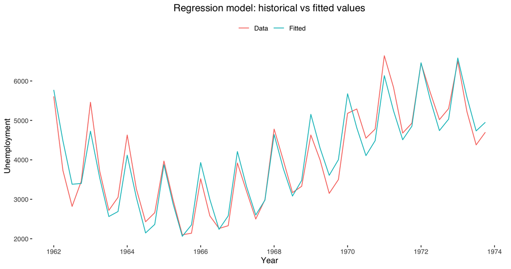

Figure 8: Regression model: quarterly unemployment in Canada in 1962-1973 vs. fitted values

```r
autoplot(training_data, series="Data") +
  autolayer(fitted(regression_model), series="Fitted") +
  xlab("Year") + ylab("Unemployment") +
  ggtitle("Regression model: historical vs fitted values") +
  guides(color = guide_legend(title = "")) +
    theme_tufte(base_family = "Helvetica") +
    theme(
      plot.title = element_text(hjust = 0.5),
      legend.position = "top"
    )
```

The residual standard error is relatively low (366.9), suggesting that the model provides a satisfactory fit to the data. Based on the Shapiro-Wilk test, there is no sufficient evidence to conclude that the residuals significantly depart from a normal distribution, indicating that the assumption of normality may be reasonable.

```r
# Test for normality
kableExtra::kbl(glance(shapiro.test(regression_model$residuals)), digits = 2, caption = "Shapiro-Wilk test of the regression model's training residuals")|>
  kable_styling(
    position = "center",
    full_width = FALSE
  )
```

Table 2: Shapiro-Wilk test of the regression model’s training residuals

| statistic | p.value | method |
| --- | --- | --- |
| 0.98 | 0.79 | Shapiro-Wilk normality test |

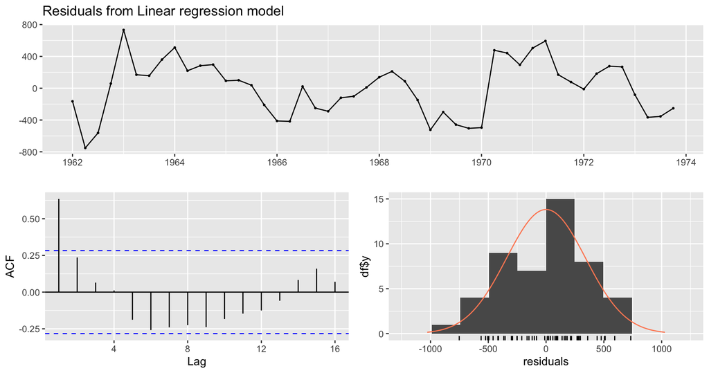

Figure 9: Training residuals from the regression model

```
    Breusch-Godfrey test for serial correlation of order up to 10

data:  Residuals from Linear regression model
LM test = 27.31, df = 10, p-value = 0.002326
```

```r
# Plot histogram of residuals
checkresiduals(regression_model)
```

However, the Breusch-Godfrey test, indicating evidence of serial correlation in the residuals from the linear regression model, and the residuals’ Autocorrelation Function plot reveals significant autocorrelation at lag 1, suggesting a violation of the assumption of independence.

Subsequently, the Ljung-Box test confirms significant autocorrelation in the training residuals at lag 1, indicating that a time series model explicitly addressing autocorrelation, such as an ARIMA model, may offer a better fit.

```r
# Perform Ljung-Box test on the residuals
ljung_box_test <- Box.test(regression_model$residuals, lag = 1, type = "Ljung-Box")

kableExtra::kbl(glance((ljung_box_test)), digits = 2, caption = "Box-Ljung test of the regression model's training residuals")|>
  kable_styling(
    position = "center",
    full_width = FALSE
  )
```

Table 3: Box-Ljung test of the regression model’s training residuals

| statistic | p.value | parameter | method |
| --- | --- | --- | --- |
| 20.59 | 0 | 1 | Box-Ljung test |

When evaluating the regression model’s forecasting performance on future data displayed as a dashed black line in Figure 10, we notice that it predicts unemployment reasonably well for the first four quarters, with the future data lying within the 80% confidence interval. However, future unemployment sharply increased during the last four quarters, contrary to the regression model’s forecast, which exhibits a clear downward trend. This discrepancy suggests that the model may not capture specific patterns or information present in the data.

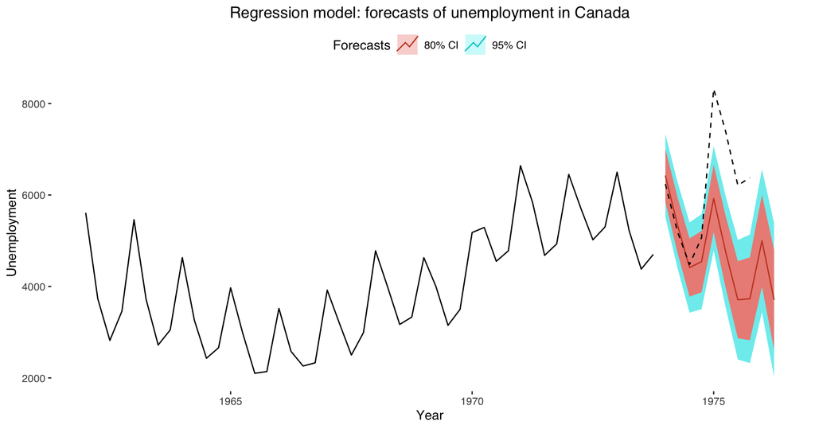

Figure 10: Regression model’s eight-quarter forecast of unemployment in Canada

```r
# Forecast
forecast_regression <- forecast(regression_model, h = 8, PI = TRUE, level = c(0.8, 0.95))

# Plot the forecast and test data together
autoplot(training_data) +
  autolayer(forecast(regression_model, level = c(0.95)), series = "95% CI") +
      autolayer(forecast(regression_model, level = c(0.8)), series = "80% CI") +
  autolayer(test_data, color = "black", linetype = "dashed", series = "Future Data") +
  xlab("Year") +
  ylab("Unemployment") +
  ggtitle("Regression model: forecasts of unemployment in Canada") +
  guides(color = guide_legend(title = "Forecasts"),
         linetype = guide_legend(title = "Future Data")) +
    theme_tufte(base_family = "Helvetica") +
    theme(
      plot.title = element_text(hjust = 0.5),
      legend.position = "top"
    )
```

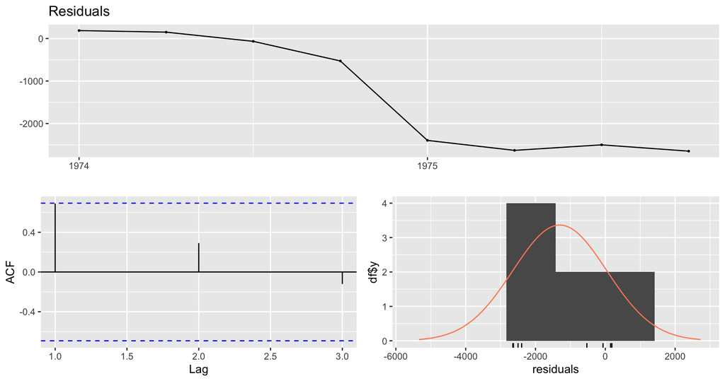

Figure 11: Regression model: out-of-sample residuals

```
    Ljung-Box test

data:  Residuals
Q* = 6.7876, df = 3, p-value = 0.07898

Model df: 0.   Total lags used: 3
```

```r
# Calculate residuals
residuals_regression <- forecast_regression$mean - test_data
checkresiduals(residuals_regression)
```

We can use various evaluation metrics, such as MAE, RMSE, and MAPE, to evaluate the accuracy of the regression model’s forecasts of future data.

```r
# Calculate evaluation metrics
mae_regression <- mean(abs(residuals_regression))
rmse_regression <- sqrt(mean(residuals_regression^2))
mape_regression <- mean(abs(residuals_regression / test_data)) * 100
bias_regression <- mean(residuals_regression)

# Create a data frame for the metrics
evaluation_regression <- data.frame(
  Metric = c("Mean Absolute Error (MAE)", "Root Mean Squared Error (RMSE)",
             "Mean Absolute Percentage Error (MAPE)", "Forecast Bias"),
  Value = c(mae_regression, rmse_regression, mape_regression, bias_regression)
)

# Remove column names
colnames(evaluation_regression) <- NULL

# Print the data frame

kableExtra::kbl(evaluation_regression, digits = 2, caption = "Error measures evaluating the regression model's out-of-sample accuracy")|>
  kable_styling(
    position = "center",
    full_width = FALSE
  )
```

Table 4: Error measures evaluating the regression model’s out-of-sample accuracy

| Mean Absolute Error (MAE) | 1388.75 |
| --- | --- |
| Root Mean Squared Error (RMSE) | 1812.55 |
| Mean Absolute Percentage Error (MAPE) | 20.51 |
| Forecast Bias | -1304.33 |

An RMSE of 1812.552 indicates that, on average, the forecasted values deviate from the actual future values by approximately 1812.552 units. The MAPE suggests that, on average, the forecasts deviate from the actual future values by approximately 20.50523%. The bias indicates that, on average, the forecasts tend to underestimate the actual values by approximately 1304.327 units.

Overall, the forecasting performance of this model seems to have moderate accuracy. The MAE, RMSE, and MAPE values suggest that the forecasts have a reasonable level of accuracy, although there is room for improvement. Additionally, the negative bias indicates a tendency for the forecasts to be consistently lower than the actual values.

Notably, the significant jump in unemployment observed in 1975, the highest value throughout the observation period, indicates an extraordinary event that the model could not consider. This highlights the challenge of forecasting, which assumes that future patterns and behaviours will resemble those observed in the past.

## Exponential smoothing modelling, analysis and forecasting

To manually fit a model from the exponential smoothing family, tailored for time series data exhibiting trend and seasonality, the Holt-Winters method is a suitable choice. This method extends simple exponential smoothing to accommodate data with both trend and seasonality. We will fit the Holt-Winters model incorporating multiplicative error, additive trend with damping, and multiplicative seasonality components (ETS(M,Ad,M)).

```r
# Fit the Holt-Winters model with multiplicative trend and seasonality
hw_model <- ets(training_data, model="MAM", damped=TRUE)

{ cat("Exponential Smoothing model with the Holt-Winters method summary\n"); print(summary(hw_model)) }
```

```
Exponential Smoothing model with the Holt-Winters method summary
ETS(M,Ad,M)

Call:
ets(y = training_data, model = "MAM", damped = TRUE)

  Smoothing parameters:
    alpha = 0.4065
    beta  = 0.4065
    gamma = 0.5796
    phi   = 0.8758

  Initial states:
    l = 4134.9175
    b = -5.4187
    s = 0.881 0.7053 0.9446 1.4691

  sigma:  0.0855

     AIC     AICc      BIC
752.0501 757.9960 770.7621

Training set error measures:
                    ME     RMSE      MAE        MPE     MAPE      MASE
Training set -28.89258 321.5432 244.6389 -0.1225624 5.976051 0.5334049
                  ACF1
Training set 0.3023249
```

A sigma value of 0.0855 suggests that the model captures a significant portion of the variability in the training data. Additionally, the relatively low values of AIC, AICc, and BIC are positive indicators of model fit.

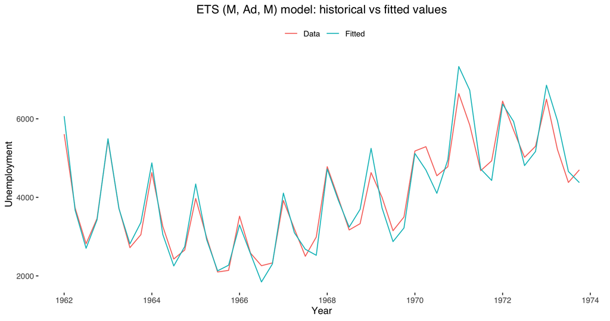

Figure 12: Exponential smoothing (ETS (M, Ad, M)) model: quarterly unemployment in Canada in 1962-1973 vs. fitted values

```r
autoplot(training_data, series="Data") +
  autolayer(fitted(hw_model), series="Fitted") +
  xlab("Year") + ylab("Unemployment") +
    ggtitle("ETS (M, Ad, M) model: historical vs fitted values") +
  guides(color = guide_legend(title = "")) +
    theme_tufte(base_family = "Helvetica") +
    theme(
      plot.title = element_text(hjust = 0.5),
      legend.position = "top"
    )
```

Upon examination of residuals, they appear to be normally distributed without any discernible patterns.

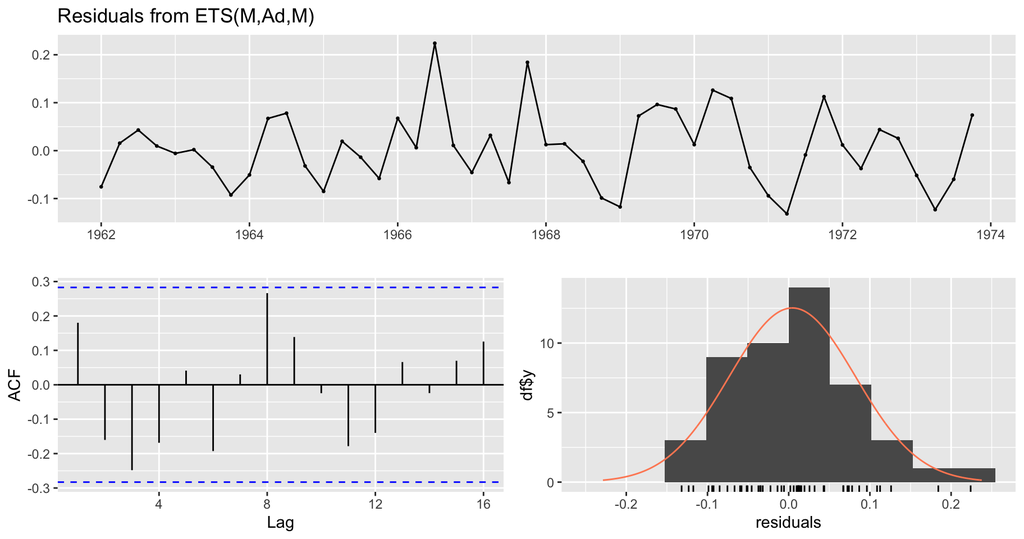

Figure 13: Exponential smoothing (ETS (M, Ad, M)) model: training residuals

```
    Ljung-Box test

data:  Residuals from ETS(M,Ad,M)
Q* = 14.359, df = 8, p-value = 0.07287

Model df: 0.   Total lags used: 8
```

```r
# Plot histogram of residuals
checkresiduals(hw_model)
```

It is supported by the Shapiro-Wilk test results, which do not provide sufficient evidence to reject the assumption of normality.

```r
# Test for normality

kableExtra::kbl(glance(shapiro.test(hw_model$residuals)), digits = 2, caption = "Shapiro-Wilk test of the exponential smoothing model's training residuals")|>
  kable_styling(
    position = "center",
    full_width = FALSE
  )
```

Table 5: Shapiro-Wilk test of the exponential smoothing model’s training residuals

| statistic | p.value | method |
| --- | --- | --- |
| 0.97 | 0.39 | Shapiro-Wilk normality test |

However, further evaluation of the model on future data is warranted to provide a comprehensive assessment.

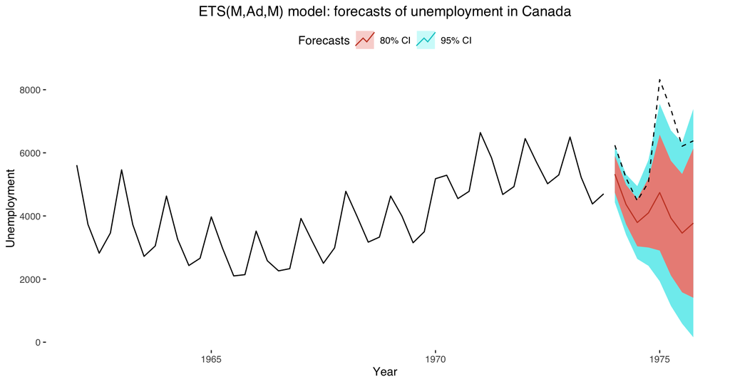

Figure 14: Exponential smoothing (ETS (M, Ad, M)) model’s eight-quarter forecast of unemployment in Canada

```r
# Forecast
forecast_hw <- forecast(hw_model, h = 8, PI = TRUE, level = c(0.8, 0.95))

# Plot the forecast and test data together
autoplot(training_data) +
  autolayer(forecast(hw_model, level = c(0.95)), series = "95% CI") +
      autolayer(forecast(hw_model, level = c(0.8)), series = "80% CI") +
  autolayer(test_data, color = "black", linetype = "dashed", series = "Future Data") +
  xlab("Year") +
  ylab("Unemployment") +
  ggtitle("ETS(M,Ad,M) model: forecasts of unemployment in Canada") +
  guides(color = guide_legend(title = "Forecasts"),
         linetype = guide_legend(title = "Future Data"))+
    theme_tufte(base_family = "Helvetica") +
    theme(
      plot.title = element_text(hjust = 0.5),
      legend.position = "top"
    )
```

This discrepancy makes it challenging to directly assess the model’s forecasting performance solely based on this plot. Therefore, we conduct residual analysis in Figure 15 to obtain a more objective evaluation and examine various evaluation metrics such as MAE, RMSE, and MAPE.

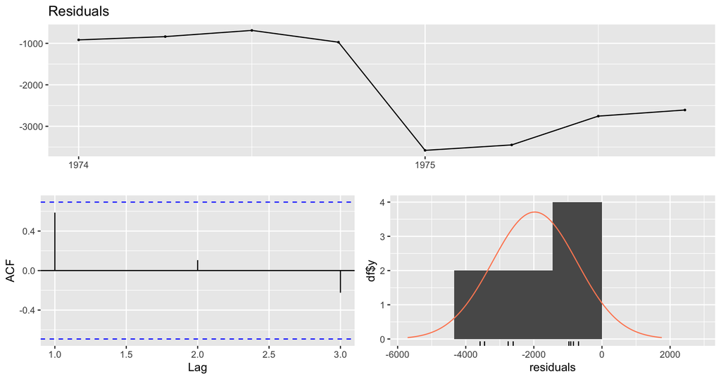

Figure 15: Exponential smoothing (ETS (M, Ad, M)) model: out-of-sample residuals

```
    Ljung-Box test

data:  Residuals
Q* = 4.8876, df = 3, p-value = 0.1802

Model df: 0.   Total lags used: 3
```

```r
# Calculate residuals
residuals_hw <- forecast_hw$mean - test_data
checkresiduals(residuals_hw)
```

The Ljung-Box Test Statistic’s p-value (0.1802) is greater than the commonly used significance level of 0.05, suggesting no significant autocorrelation in the residuals at the specified lags.

However, the model exhibits poor performance compared to the future data.

```r
# Calculate evaluation metrics
mae_hw <- mean(abs(residuals_hw))
rmse_hw <- sqrt(mean(residuals_hw^2))
mape_hw <- mean(abs(residuals_hw / test_data)) * 100
bias_hw <- mean(residuals_hw)

# Create a data frame for the metrics
evaluation_hw <- data.frame(
  Metric = c("Mean Absolute Error (MAE)", "Root Mean Squared Error (RMSE)",
             "Mean Absolute Percentage Error (MAPE)", "Forecast Bias"),
  Value = c(mae_hw, rmse_hw, mape_hw, bias_hw)
)

# Remove column names
colnames(evaluation_hw) <- NULL

# Print the data frame

kableExtra::kbl(evaluation_hw, digits = 2, caption = "Error measures evaluating ETS(M,Ad,M) model's out-of-sample accuracy")|>
  kable_styling(
    position = "center",
    full_width = FALSE
  )
```

Table 6: Error measures evaluating ETS(M,Ad,M) model’s out-of-sample accuracy

| Mean Absolute Error (MAE) | 1975.52 |
| --- | --- |
| Root Mean Squared Error (RMSE) | 2292.64 |
| Mean Absolute Percentage Error (MAPE) | 30.04 |
| Forecast Bias | -1975.52 |

High MAE and RMSE values indicate significant deviations from actual values on average, while a MAPE of 30.0379% suggests considerable discrepancies relative to actual values. A lower MAPE is desired for more accurate forecasts. Furthermore, the negative bias indicates a systematic underestimation of actual values.

In conclusion, the model’s performance is subpar, characterised by high errors, substantial deviations from actual future values, and systematic bias. Further refinement or alternative modelling approaches may be necessary to enhance forecasting accuracy.

## ARIMA modelling, analysis and forecasting

As established earlier, the historical time series data exhibits trend and seasonality components, rendering it non-stationary. This is confirmed by the Autocorrelation Function (ACF) plot in Figure 16, which displays multiple spikes outside the confidence intervals, with a notably strong and significantly positive first lag.

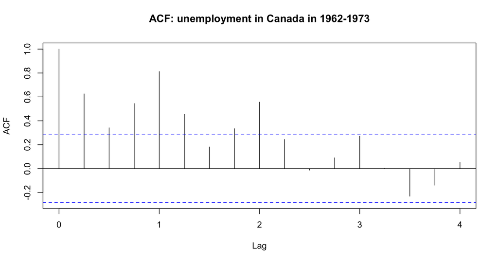

Figure 16: Autocorrelation Function (ACF) plot of the quarterly unemployment in Canada in 1962-1973

```r
acf(training_data, main = "ACF: unemployment in Canada in 1962-1973")
```

To address non-stationarity, differencing can stabilise the time series’ mean and eliminate trends and seasonality. Augmented Dickey-Fuller (ADF) and Kwiatkowski-Phillips-Schmidt-Shin (KPSS) tests are conducted to determine the necessity of differencing objectively.

```r
library(tseries)
print(adf.test(training_data, alternative = "stationary"))
```

```
    Augmented Dickey-Fuller Test

data:  training_data
Dickey-Fuller = -1.9397, Lag order = 3, p-value = 0.5982
alternative hypothesis: stationary
```

The ADF test yields a high p-value (0.5982), failing to reject the null hypothesis of non-stationarity, while the KPSS test, with a p-value of 0.01, rejects the null hypothesis of stationarity around a level:

```r
library(urca)
print(kpss.test(training_data))
```

```
    KPSS Test for Level Stationarity

data:  training_data
KPSS Level = 0.80281, Truncation lag parameter = 3, p-value = 0.01
```

As the next step, we can use `ndiffs()` and `nsdiffs()` functions to determine the appropriate number of first and seasonal differencing for the training data:

```r
{cat("Number of first differencings: ", ndiffs(training_data), "\n"); cat("Number of seasonal differencings: ", nsdiffs(training_data))}
```

```
Number of first differencings:  1
Number of seasonal differencings:  1
```

A Box-Cox transformation will not be performed due to the absence of evidence indicating variance changes.

Subsequently, the first and seasonal differencings are applied to the historical data, followed by an examination of the ACF/PACF plots in Figure 17.

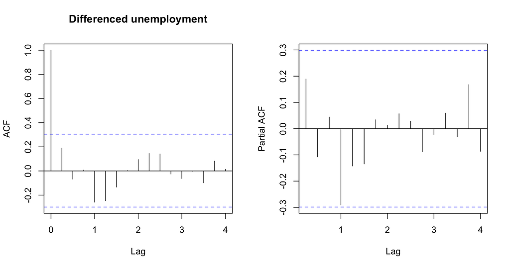

Figure 17: Autocorrelation Function (ACF) and Partial Autocorrelation Function (PACF) plots of the quarterly unemployment in Canada in 1962-1973

```r
training_diff <- diff(diff(training_data, differences = 1), lag = 4)

# Set up a multi-panel plot with 1 row and 2 columns
par(mfrow = c(1, 2))

# Plot ACF for differenced data
acf(training_diff, main = "Differenced unemployment")

# Plot PACF for differenced data
pacf(training_diff, main = "")
```

The efficacy of differencing is further confirmed by plotting the differenced historical data in Figure 18 together with performing the ADF test below, indicating stationarity of the differenced series, while the KPSS test fails to reject the null hypothesis of stationarity.

```r
print(adf.test(training_diff, alternative = "stationary"))
```

```
    Augmented Dickey-Fuller Test

data:  training_diff
Dickey-Fuller = -4.2479, Lag order = 3, p-value = 0.01
alternative hypothesis: stationary
```

```r
print(kpss.test(training_diff))
```

```
    KPSS Test for Level Stationarity

data:  training_diff
KPSS Level = 0.11986, Truncation lag parameter = 3, p-value = 0.1
```

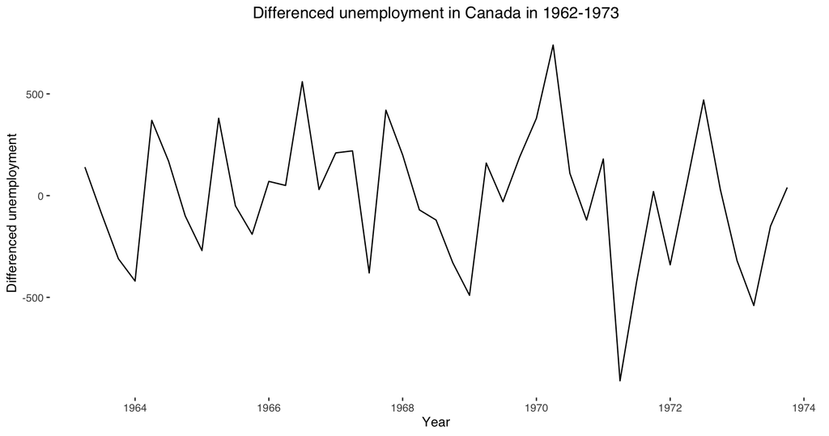

```r
# Plot Differenced Data
autoplot(training_diff)+
 ggtitle("Differenced unemployment in Canada in 1962-1973") +
    xlab("Year")+
    ylab("Differenced unemployment")+
  guides(color = guide_legend(title = "")) +
  scale_fill_manual(values = c("lightblue", "skyblue"), labels = c("Yes", "No")) +
  theme_tufte(base_family = "Helvetica") +
  theme(
    plot.title = element_text(hjust = 0.5),
    legend.position = "top"
    )
```

With stationarity achieved, modeling using ARIMA (AutoRegressive Integrated Moving Average) methods becomes feasible. Based on observations, an initial ARIMA model of ARIMA(0,1,0)(1,1,0)[4] is proposed, accounting for differencing and seasonality.

```r
arima_model <- Arima(training_data, order = c(0,1,0), seasonal = c(1,1,0))
print(summary(arima_model))
```

```
Series: training_data
ARIMA(0,1,0)(1,1,0)[4]

Coefficients:
         sar1
      -0.2806
s.e.   0.1504

sigma^2 = 97474:  log likelihood = -307.65
AIC=619.3   AICc=619.6   BIC=622.82

Training set error measures:
                    ME     RMSE      MAE       MPE     MAPE      MASE      ACF1
Training set -5.924679 292.0447 219.2004 0.2442629 5.699038 0.4779394 0.1445496
```

These statistical measures provide a way to compare the goodness of fit among different models. In this case, the log-likelihood is -307.65, and the AIC, AICc, and BIC are 619.3, 619.6, and 622.82, respectively. Lower values of AIC, AICc, and BIC indicate a better fit, suggesting that the model is relatively good compared to alternative models.

The seasonal autoregressive term (sar1) coefficient is -0.2806, indicating a negative relationship between the observations and their seasonal lagged values. This coefficient’s standard error (s.e.) is 0.1504, suggesting a relatively precise estimate.

The MPE (Mean Percentage Error) is 0.2442629%, which measures the average relative error. It’s close to 0, indicating that, on average, the model’s forecasts are accurate.

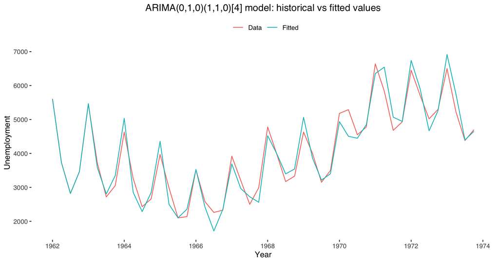

Figure 19: ARIMA(0,1,0)(1,1,0)[4] model: quarterly unemployment in Canada in 1962-1973 vs fitted values

```r
autoplot(training_data, series="Data") +
  autolayer(fitted(arima_model), series="Fitted") +
  xlab("Year") + ylab("Unemployment") +
 ggtitle("ARIMA(0,1,0)(1,1,0)[4] model: historical vs fitted values") +
  guides(color = guide_legend(title = "")) +
  scale_fill_manual(values = c("lightblue", "skyblue"), labels = c("Yes", "No")) +
  theme_tufte(base_family = "Helvetica") +
  theme(
    plot.title = element_text(hjust = 0.5),
    legend.position = "top"
    )
```

Residual analysis in Figure 20 reveals normally distributed residuals with no significant autocorrelation, further affirming the adequacy of the ARIMA model.

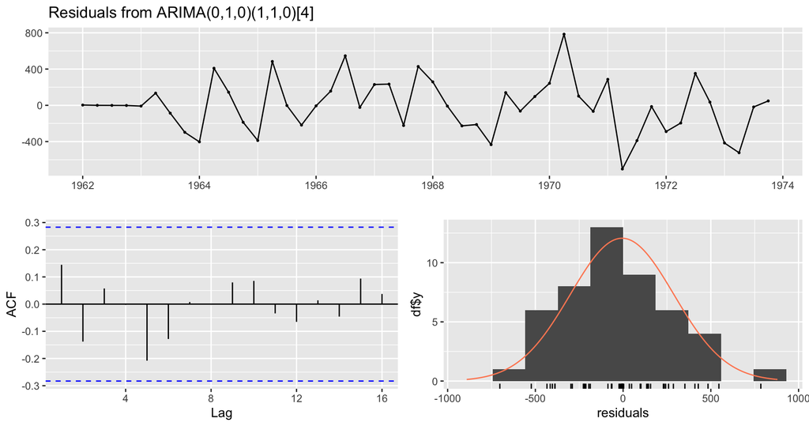

Figure 20: ARIMA(0,1,0)(1,1,0)[4] model: training residuals

```
    Ljung-Box test

data:  Residuals from ARIMA(0,1,0)(1,1,0)[4]
Q* = 5.5894, df = 7, p-value = 0.5884

Model df: 1.   Total lags used: 8
```

```r
# Plot histogram of residuals
checkresiduals(arima_model)
```

The Ljung-Box test result, with a p-value of 0.5884, indicates that the model adequately captures the temporal dependence structure present in the historical data.

The Shapiro-Wilk test, which assesses the normality of the residuals from the ARIMA model, does not provide sufficient evidence to reject the null hypothesis of normality. This suggests that the residuals from the ARIMA model are approximately normally distributed.

```r
# Test for normality
print(shapiro.test(arima_model$residuals))
```

```
    Shapiro-Wilk normality test

data:  arima_model$residuals
W = 0.98638, p-value = 0.8451
```

Upon forecasting performance evaluation against future data, the ARIMA model exhibits reasonably low errors and bias, indicating satisfactory performance, albeit challenges in predicting extraordinary spikes in future data in Figure 21.

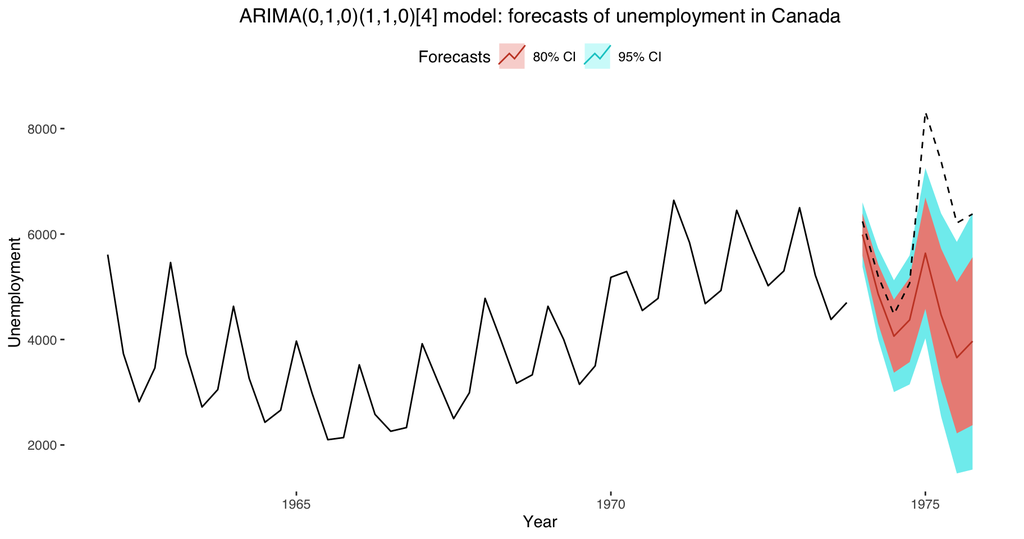

Figure 21: ARIMA(0,1,0)(1,1,0)[4] model’s eight-quarter forecast of unemployment in Canada

```r
# Forecast
forecast_arima <- forecast(arima_model, h = 8, PI = TRUE, level = c(0.8, 0.95))

# Plot the forecast and test data together
autoplot(training_data) +
  autolayer(forecast(arima_model, level = c(0.95)), series = "95% CI") +
      autolayer(forecast(arima_model, level = c(0.8)), series = "80% CI") +
  autolayer(test_data, color = "black", linetype = "dashed", series = "Future Data") +
  xlab("Year") +
  ylab("Unemployment") +
  ggtitle("ARIMA(0,1,0)(1,1,0)[4] model: forecasts of unemployment in Canada") +
  guides(color = guide_legend(title = "Forecasts"),
         linetype = guide_legend(title = "Future Data"))+
  scale_fill_manual(values = c("lightblue", "skyblue"), labels = c("Yes", "No")) +
  theme_tufte(base_family = "Helvetica") +
  theme(
    plot.title = element_text(hjust = 0.5),
    legend.position = "top"
    )
```

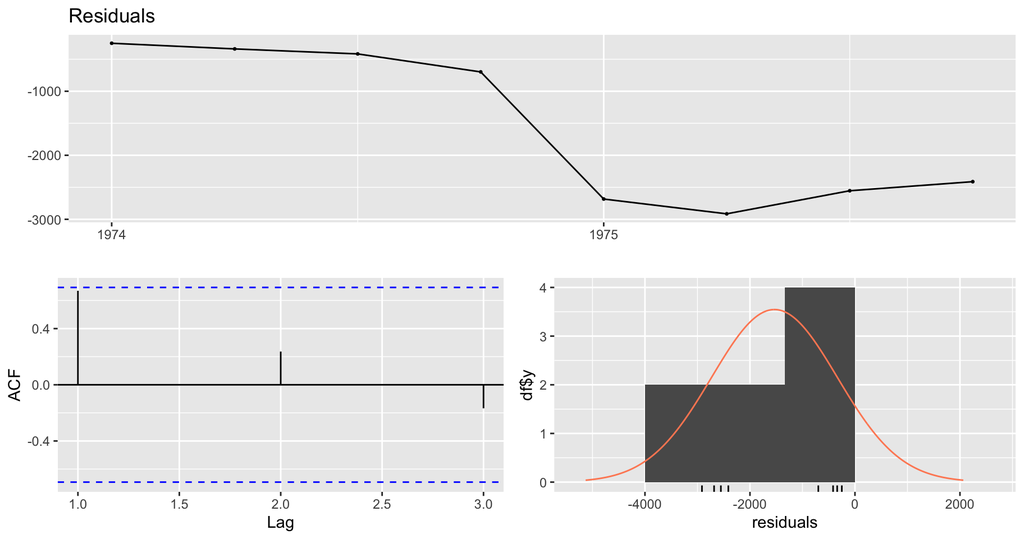

Figure 22: ARIMA(0,1,0)(1,1,0)[4] model: out-of-sample residuals

```
    Ljung-Box test

data:  Residuals
Q* = 6.3136, df = 3, p-value = 0.09731

Model df: 0.   Total lags used: 3
```

```r
# Calculate residuals
residuals_arima <- forecast_arima$mean - test_data

checkresiduals(residuals_arima)
```

The error measures suggest that the model’s forecasts have relatively low errors and bias, indicating reasonably good performance, considering the future data had extraordinary spikes.

```r
# Calculate evaluation metrics
mae_arima <- mean(abs(residuals_arima))
rmse_arima <- sqrt(mean(residuals_arima^2))
mape_arima <- mean(abs(residuals_arima / test_data)) * 100
bias_arima <- mean(residuals_arima)

# Create a data frame for the metrics
evaluation_arima <- data.frame(
  Metric = c("Mean Absolute Error (MAE)", "Root Mean Squared Error (RMSE)",
             "Mean Absolute Percentage Error (MAPE)", "Forecast Bias"),
  Value = c(mae_arima, rmse_arima, mape_arima, bias_arima)
)

# Remove column names
colnames(evaluation_arima) <- NULL

# Print the data frame

kableExtra::kbl(evaluation_arima, digits = 2, caption = "Error measures evaluating the ARIMA model’s out-of-sample accuracy")|>
  kable_styling(
    position = "center",
    full_width = FALSE
  )
```

Table 7: Error measures evaluating the ARIMA model’s out-of-sample accuracy

| Mean Absolute Error (MAE) | 1533.37 |
| --- | --- |
| Root Mean Squared Error (RMSE) | 1899.72 |
| Mean Absolute Percentage Error (MAPE) | 23.03 |
| Forecast Bias | -1533.37 |

Comparative analysis of Mean Absolute Percentage Errors (MAPEs) among the three forecasting models helps identify the most suitable model. It is a reasonable approach, especially if the models have different structures or complexities, such as the regression model, which includes polynomial terms. MAPE is a relative error metric that accounts for the magnitude of the forecasted values, which can be helpful when comparing models with different scales:

```r
# Store evaluation metrics for each model in a data frame
evaluation_metrics <- data.frame(
  Model = c("ARIMA", "Exponential Smoothing", "Regression"),
  MAE = c(mae_arima, mae_hw, mae_regression),
  RMSE = c(rmse_arima, rmse_hw, rmse_regression),
  MAPE = c(mape_arima, mape_hw, mape_regression),
  Bias = c(bias_arima, bias_hw, bias_regression)
)

# Print the evaluation metrics for comparison

kableExtra::kbl(evaluation_metrics, digits = 2, caption = "Error measures evaluating out-of-sample accuracy of the three models")|>
  kable_styling(
    position = "center",
    full_width = FALSE
  )
```

Table 8: Error measures evaluating out-of-sample accuracy of the three models

| Model | MAE | RMSE | MAPE | Bias |
| --- | --- | --- | --- | --- |
| ARIMA | 1533.37 | 1899.72 | 23.03 | -1533.37 |
| Exponential Smoothing | 1975.52 | 2292.64 | 30.04 | -1975.52 |
| Regression | 1388.75 | 1812.55 | 20.51 | -1304.33 |

```r
# Select the model with the lowest values for the evaluation metrics
best_model <- evaluation_metrics[which.min(evaluation_metrics$MAPE), ]

# Print the best model
cat("Best Model based on MAPE:", best_model$Model, "\n")
```

```
Best Model based on MAPE: Regression
```

# Key Findings and Business Implications

Analysis of quarterly unemployment in Canada showed that traditional forecasting models, including regression, exponential smoothing, and ARIMA, effectively captured general trends before the 1975 recession. Regression models performed particularly well, providing reliable forecasts under stable economic conditions.

However, the 1973-1975 global recession brought abrupt shifts in unemployment due to oil crises, trade disruptions, and industrial restructuring. Forecasting models struggled during this period, highlighting the limitations of relying solely on historical trends in highly volatile economic environments.

From a business perspective, this underscores the importance of scenario planning and adaptive forecasting. While historical patterns inform baseline predictions, organisations must account for potential shocks and variability to avoid under-preparedness.

Feature analysis and model evaluation showed that structured, high-frequency data enables organisations to detect trends early, helping to adjust resource allocation, plan hiring or layoffs, and manage financial exposure in advance.

# Concusion & So What

The project demonstrates that time-series forecasting is more than a technical exercise - it turns historical data into strategic insight. For businesses and policymakers:

• Forecasts allow proactive workforce planning, helping mitigate risks of overstaffing or shortages during economic fluctuations.

• Scenario-aware forecasting supports financial risk management, guiding investment and budgeting decisions under uncertain labour conditions.

• Trend, seasonal, and cyclical insights inform strategic decisions, such as targeting growth in resilient sectors or adjusting operations during potential recessions.

# References

Bank of Canada (1999) *Canadian economic performance at the end of the twentieth century.* Available at: https://www.bankofcanada.ca/1999/06/canadian-economic-performance-end-twentieth-century/ (Accessed: 29 March 2024).

Brozyna J., Mentel G., Szetela B. (2016), ‘Influence of double seasonality on economic forecasts on the example of energy demand’, *Journal of International Studies*, Vol. 9, No 3, pp. 9-20. Available at: https://doi.org/10.14254/2071-8330.2016/9-3/1.

Koning, A.J., Franses, P.H., Hibon, M. and Stekler, H.O. (2005) ‘The M3 competition: Statistical tests of the results’, *International Journal of Forecasting*, 21(3), pp.397–409. Available at: https://doi.org/10.1016/j.ijforecast.2004.10.003.

Makridakis, S. and Hibon, M. (2000) ‘The M3-Competition: results, conclusions and implications’, *International Journal of Forecasting*, 16(4), pp.451–476. Available at: https://doi.org/10.1016/s0169-2070(00)00057-1.